# Assignment7_MinHashLSH_JaccardSimilarity_Text

# Fit countvectorizer to create word features

```python
vectorize = CountVectorizer(inputCol="filtered_words", outputCol="features", minDF=1.0)
df_vectorize = vectorize.fit(df_text).transform(df_text)

display(df_vectorize.limit(5).toPandas())
```

```
24/05/02 04:51:09 WARN org.apache.spark.scheduler.DAGScheduler: Broadcasting large task binary with size 4.1 MiB
```

|  | id | text | filtered_words | features |
| --- | --- | --- | --- | --- |
| 0 | 0 | The Daily Ripple-News Music Ideas - TikTok choking video incites suicide: Italian policeThe Daily Ripple-News Music IdeasSwitch to desktopHomeWorld PoliticsU.S. Politics »EconomyFood/HealthArt/Music »… | [Daily, RippleNews, Music, Ideas, TikTok, choking, video, incites, suicide, Italian, policeThe, Daily, RippleNews, Music, IdeasSwitch, desktopHomeWorld, PoliticsUS, Politics EconomyFoodHealthArtMusic … | (2.0, 0.0, 0.0, 3.0, 1.0, 1.0, 0.0, 0.0, 0.0, 0.0, 0.0, 0.0, 0.0, 0.0, 0.0, 1.0, 0.0, 0.0, 0.0, 0.0, 0.0, 0.0, 0.0, 1.0, 0.0, 0.0, 0.0, 2.0, 0.0, 0.0, 0.0, 0.0, 0.0, 0.0, 1.0, 0.0, 0.0, 0.0, 0.0, 0.0,… |
| 1 | 1 | Dr Pepper Tuition Giveaway Program Takes to TikTok with the #IDeserveTuitionContest \| National \| whatsuppub.comYou have permission to edit this article. EditCloseSign Up Log In Dashboard LogoutMy Ac… | [Dr, Pepper, Tuition, Giveaway, Program, Takes, TikTok, IDeserveTuitionContest, National, whatsuppubcomYou, permission, edit, article, EditCloseSign, Log, Dashboard, LogoutMy, Account, Dashboard, Prof… | (6.0, 1.0, 1.0, 2.0, 0.0, 6.0, 0.0, 0.0, 0.0, 0.0, 0.0, 0.0, 0.0, 0.0, 0.0, 1.0, 1.0, 1.0, 0.0, 1.0, 0.0, 1.0, 0.0, 2.0, 0.0, 0.0, 0.0, 1.0, 0.0, 0.0, 0.0, 0.0, 1.0, 0.0, 0.0, 0.0, 1.0, 1.0, 0.0, 0.0,… |
| 2 | 2 | Angry rant from a Neenah Bath & Body Works customer goes viral on TikTok nearly 10 years after the original video was posted – WisconsinReport.com WisconsinReport.com - Serving Internet Readers Since … | [Angry, rant, Neenah, Bath, Body, Works, customer, goes, viral, TikTok, nearly, 10, years, original, video, posted, WisconsinReportcom, WisconsinReportcom, Serving, Internet, Readers, Since, 2002Skip,… | (3.0, 0.0, 0.0, 5.0, 0.0, 1.0, 0.0, 11.0, 1.0, 0.0, 1.0, 0.0, 0.0, 0.0, 0.0, 0.0, 0.0, 0.0, 1.0, 2.0, 0.0, 0.0, 0.0, 0.0, 0.0, 0.0, 2.0, 0.0, 0.0, 1.0, 1.0, 0.0, 0.0, 3.0, 0.0, 3.0, 0.0, 0.0, 1.0, 0.0… |
| 3 | 3 | Amid Ban, Tiktok Shares Info On Compliance With New Rules \| Indian Defence NewsHomeIndiaAll Indian Defence NewsArmyAir ForceNavyChief of Defence StaffAksai ChinArtificial IntelligenceAnti-Satellite M… | [Amid, Ban, Tiktok, Shares, Info, Compliance, New, Rules, Indian, Defence, NewsHomeIndiaAll, Indian, Defence, NewsArmyAir, ForceNavyChief, Defence, StaffAksai, ChinArtificial, IntelligenceAntiSatellit… | (7.0, 4.0, 11.0, 1.0, 0.0, 1.0, 0.0, 0.0, 0.0, 0.0, 1.0, 0.0, 1.0, 0.0, 2.0, 2.0, 0.0, 1.0, 3.0, 0.0, 0.0, 0.0, 0.0, 1.0, 1.0, 4.0, 0.0, 0.0, 0.0, 0.0, 0.0, 0.0, 0.0, 0.0, 0.0, 0.0, 0.0, 0.0, 0.0, 0.0… |
| 4 | 4 | TikTok User Shares FaceTime Call With Matthew Perry - 1010 WCSI Friday, May 7, 2021 1010 WCSINews Talk 1010 WCSI ShowsAM ColumbusColumbus News and ViewsRadio AuctionTalk ShowsProgram ScheduleNewsLocal… | [TikTok, User, Shares, FaceTime, Call, Matthew, Perry, 1010, WCSI, Friday, May, 2021, 1010, WCSINews, Talk, 1010, WCSI, ShowsAM, ColumbusColumbus, News, ViewsRadio, AuctionTalk, ShowsProgram, Schedule… | (3.0, 0.0, 0.0, 2.0, 2.0, 2.0, 2.0, 0.0, 2.0, 0.0, 2.0, 1.0, 0.0, 0.0, 0.0, 0.0, 1.0, 0.0, 0.0, 0.0, 0.0, 0.0, 1.0, 0.0, 0.0, 0.0, 0.0, 1.0, 0.0, 0.0, 0.0, 0.0, 0.0, 0.0, 0.0, 1.0, 0.0, 0.0, 0.0, 0.0,… |

# Fit MinHashLSH to create hash table

# These code snippets apply MinHashLSH to hash the feature vectors generated by CountVectorizer, allowing for efficient similarity search and nearest neighbor retrieval in high-dimensional vector spaces, especially useful for large-scale datasets where exact similarity search might be computationally expensive.

```python
mh = MinHashLSH(inputCol="features", outputCol="hashes", numHashTables=5)
model = mh.fit(df_vectorize)
df_hashed_text = mh.fit(df_vectorize).transform(df_vectorize).cache()

display(df_hashed_text.limit(3).toPandas())
```

```
24/05/02 04:51:44 WARN org.apache.spark.scheduler.DAGScheduler: Broadcasting large task binary with size 4.1 MiB
```

|  | id | text | filtered_words | features | hashes |
| --- | --- | --- | --- | --- | --- |
| 0 | 0 | The Daily Ripple-News Music Ideas - Biden team shelves plan to force TikTok sale: ReportThe Daily Ripple-News Music IdeasSwitch to desktopHomeWorld PoliticsU.S. Politics »EconomyFood/HealthArt/Music »… | [Daily, RippleNews, Music, Ideas, Biden, team, shelves, plan, force, TikTok, sale, ReportThe, Daily, RippleNews, Music, IdeasSwitch, desktopHomeWorld, PoliticsUS, Politics EconomyFoodHealthArtMusic Mu… | (3.0, 0.0, 0.0, 1.0, 1.0, 1.0, 0.0, 0.0, 0.0, 0.0, 0.0, 0.0, 0.0, 0.0, 0.0, 1.0, 0.0, 0.0, 0.0, 0.0, 0.0, 0.0, 0.0, 1.0, 1.0, 0.0, 0.0, 2.0, 0.0, 0.0, 0.0, 0.0, 0.0, 0.0, 1.0, 0.0, 0.0, 0.0, 0.0, 0.0,… | [[2027525.0], [9965036.0], [21976729.0], [14413751.0], [19185031.0]] |
| 1 | 1 | TikTok looks to ‘promote kindness’ with new pop-up feature – The PioneerSubmit SearchSearch RSS FeedYouTubeInstagramTwitterFacebookSubmit SearchSearchClose MenuSearchFeaturesArts & LifeCampusOpinionCa… | [TikTok, looks, promote, kindness, new, popup, feature, PioneerSubmit, SearchSearch, RSS, FeedYouTubeInstagramTwitterFacebookSubmit, SearchSearchClose, MenuSearchFeaturesArts, LifeCampusOpinionCandida… | (9.0, 4.0, 1.0, 0.0, 0.0, 2.0, 0.0, 0.0, 0.0, 0.0, 2.0, 0.0, 1.0, 0.0, 1.0, 1.0, 0.0, 1.0, 2.0, 0.0, 0.0, 0.0, 0.0, 0.0, 0.0, 1.0, 0.0, 0.0, 0.0, 0.0, 0.0, 0.0, 0.0, 0.0, 0.0, 1.0, 0.0, 2.0, 0.0, 0.0,… | [[19185451.0], [11447295.0], [5735548.0], [18266786.0], [4153749.0]] |
| 2 | 2 | How a deepfake Tom Cruise on TikTok turned into a very real AI company - USweeklyFriday, 06 August 2021Send search form Todays newsWorldU.S. NationalPoliticsBusinessTechnologySportsEntertainmentBeaut… | [deepfake, Tom, Cruise, TikTok, turned, real, AI, company, USweeklyFriday, 06, August, 2021Send, search, form, Todays, newsWorldUS, NationalPoliticsBusinessTechnologySportsEntertainmentBeauty, HealthL… | (3.0, 0.0, 0.0, 0.0, 0.0, 1.0, 0.0, 0.0, 0.0, 0.0, 0.0, 0.0, 0.0, 1.0, 0.0, 0.0, 0.0, 0.0, 0.0, 0.0, 0.0, 0.0, 0.0, 0.0, 0.0, 0.0, 0.0, 0.0, 0.0, 0.0, 0.0, 0.0, 0.0, 0.0, 0.0, 0.0, 0.0, 0.0, 0.0, 0.0,… | [[39873116.0], [3260711.0], [478804.0], [31041813.0], [27890495.0]] |

# Step 4. Establish similarity threshold and return near-duplicate records

# **Note:** we are joining dataframe to itself to get near-duplicate pairs

**Also note:** you do not join on specific variables like keys or IDs. Instead, you join based on the similarity of feature vectors, which is determined using LSH algorithms.

These code use the MinHashLSH model to find pairs of documents with Jaccard similarities above a specified threshold (jaccard_distance). The resulting DataFrame (df_dups_text) contains pairs of similar documents along with their Jaccard distances and text content.

# a Jaccard distance of 0.3 means that pairs of sets with a **Jaccard similarity (1 - Jaccard distance) greater than or equal to 0.7 will be considered similar.**

```python
jaccard_distance = 0.3 # the threshold, more strict threshold here

df_dups_text = model.approxSimilarityJoin(df_hashed_text, df_hashed_text, jaccard_distance).filter("datasetA.id < datasetB.id").select(
            col("distCol"),
            col("datasetA.id").alias("id_A"),
            col("datasetB.id").alias("id_B"),
            col('datasetA.text').alias('text_A'),
            col('datasetB.text').alias('text_B'),
#             col('datasetA.list_of_words').alias('words_A'),
#             col('datasetB.list_of_words').alias('words_B')
            )
```

```python
%%time

df_dups_30 = df_dups_text
df_dups_text.cache()
df_dups_text.limit(3).toPandas()
```

```
24/05/02 04:53:55 WARN org.apache.spark.scheduler.DAGScheduler: Broadcasting large task binary with size 4.1 MiB
24/05/02 04:54:08 WARN org.apache.spark.scheduler.DAGScheduler: Broadcasting large task binary with size 4.3 MiB
[Stage 30:>                                                         (0 + 1) / 1]
```

```
CPU times: user 69.5 ms, sys: 17.2 ms, total: 86.7 ms
Wall time: 3min 20s
```

|  | distCol | id_A | id_B | text_A | text_B |
| --- | --- | --- | --- | --- | --- |
| 0 | 0.292517 | 0 | 482 | The Daily Ripple-News Music Ideas - Biden team shelves plan to force TikTok sale: ReportThe Daily Ripple-News Music IdeasSwitch to desktopHomeWorld PoliticsU.S. Politics »EconomyFood/HealthArt/Music »… | The Daily Ripple-News Music Ideas - ByteDance: TikTok's co-founder to step down as chief executiveThe Daily Ripple-News Music IdeasSwitch to desktopHomeWorld PoliticsU.S. Politics »EconomyFood/HealthA… |
| 1 | 0.293286 | 80 | 3160 | White House drops Trump orders trying to ban TikTok, WeChattornadohurricanestrong-t-stormswintry-mixfreezing-rainfreezing-drizzlelight-rainrainflurriessnowblowing-snowsleetfogwindcloudymostly-cloudy-n… | White House drops Trump orders trying to ban TikTok, WeChattornadohurricanestrong-t-stormswintry-mixfreezing-rainfreezing-drizzlelight-rainrainflurriessnowblowing-snowsleetfogwindcloudymostly-cloudy-n… |
| 2 | 0.240426 | 85 | 4614 | Gamelancer, the largest multi-channel gaming network on TikTok, reaches 30,000,0000+ followersSkip to contentLiveNewsWeatherBack to SchoolContestsPodcastsSubmit News TipSubmit Photos and VideosNewsLoc… | Gamelancer, the largest multi-channel gaming network on TikTok, reaches 30,000,0000+ followersSkip to contentWin StuffPine Belt MarketplacePine Belt ConnectJobsLaw CallMotivational MomentsWild Wednesd… |

```python
type(df_dups_30)
```

```
pyspark.sql.dataframe.DataFrame
```

[figure not shown]

```python
records = df_hashed_text.count()
# This line counts the total number of records (rows) in the DataFrame df_hashed_text, which contains the hashed text data.

dups = df_dups_text.select('id_A').distinct().count()
# This line counts the number of distinct IDs from the 'id_A' column in the DataFrame df_dups_text.
# These IDs represent the first document in each pair of similar documents found during the approximate similarity join operation.
# Counting the distinct IDs gives us the count of unique documents that are found to be similar to at least one other document.

uniques = records - dups

print ('Total records: ', records)
print ('Duplicate titles based on {', jaccard_distance, '} jaccard distance: ', dups)
print ('Unique titles based on {', jaccard_distance, '} jaccard distance: ', jaccard_distance, ': ', uniques)
```

```
24/05/02 05:00:04 WARN org.apache.spark.scheduler.DAGScheduler: Broadcasting large task binary with size 4.1 MiB
24/05/02 05:00:05 WARN org.apache.spark.scheduler.DAGScheduler: Broadcasting large task binary with size 4.3 MiB
[Stage 34:>                                                         (0 + 1) / 1]
```

```
Total records:  5000
Duplicate titles based on { 0.3 } jaccard distance:  557
Unique titles based on { 0.3 } jaccard distance:  0.3 :  4443
```

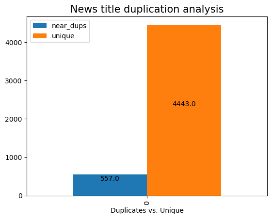

```python
dups_df = pd.DataFrame.from_dict({'near_dups': [dups], 'unique': [uniques]})

ax=dups_df.plot(kind = 'bar',y=['near_dups', 'unique'], fontsize=10, color=['C0', 'C1'], align='center', width=0.8, xlabel="Duplicates vs. Unique")
ax.set_title('News title duplication analysis', fontsize=15)
for p in ax.patches:
       ax.annotate(format(p.get_height(), '.1f'),
                   (p.get_x() + p.get_width() / 2., p.get_height()/2),
                   ha = 'center', va = 'center',
                   xytext = (0, 9),
                   textcoords = 'offset points')
```

# a Jaccard distance of 0.5 means that pairs of sets with a **Jaccard similarity (1 - Jaccard distance) greater than or equal to 0.5 will be considered similar.**

```python
jaccard_distance = 0.5

df_dups_text = model.approxSimilarityJoin(df_hashed_text, df_hashed_text, jaccard_distance).filter("datasetA.id < datasetB.id").select(
            col("distCol"),
            col("datasetA.id").alias("id_A"),
            col("datasetB.id").alias("id_B"),
            col('datasetA.text').alias('text_A'),
            col('datasetB.text').alias('text_B'),
#             col('datasetA.list_of_words').alias('words_A'),
#             col('datasetB.list_of_words').alias('words_B')
            )
```

```python
%%time

df_dups_50 = df_dups_text
df_dups_text.cache()
df_dups_text.limit(5).toPandas()
```

```
24/05/02 05:01:07 WARN org.apache.spark.scheduler.DAGScheduler: Broadcasting large task binary with size 4.1 MiB
24/05/02 05:01:23 WARN org.apache.spark.scheduler.DAGScheduler: Broadcasting large task binary with size 4.3 MiB
[Stage 38:>                                                         (0 + 1) / 1]
```

```
CPU times: user 70 ms, sys: 16.5 ms, total: 86.6 ms
Wall time: 3min 24s
```

|  | distCol | id_A | id_B | text_A | text_B |
| --- | --- | --- | --- | --- | --- |
| 0 | 0.346154 | 0 | 4202 | The Daily Ripple-News Music Ideas - Biden team shelves plan to force TikTok sale: ReportThe Daily Ripple-News Music IdeasSwitch to desktopHomeWorld PoliticsU.S. Politics »EconomyFood/HealthArt/Music »… | The Daily Ripple-News Music Ideas - The Gen Z climate activists going viral on TikTokThe Daily Ripple-News Music IdeasSwitch to desktopHomeWorld PoliticsU.S. Politics »EconomyFood/HealthArt/Music »Mus… |
| 1 | 0.374233 | 0 | 3591 | The Daily Ripple-News Music Ideas - Biden team shelves plan to force TikTok sale: ReportThe Daily Ripple-News Music IdeasSwitch to desktopHomeWorld PoliticsU.S. Politics »EconomyFood/HealthArt/Music »… | The Daily Ripple-News Music Ideas - Chinese TikTok influencers apologise for videos of lavish spending including a US$1,500 haircut, US$53,000 bed and a US$61,000 suitThe Daily Ripple-News Music Ideas… |
| 2 | 0.312057 | 0 | 566 | The Daily Ripple-News Music Ideas - Biden team shelves plan to force TikTok sale: ReportThe Daily Ripple-News Music IdeasSwitch to desktopHomeWorld PoliticsU.S. Politics »EconomyFood/HealthArt/Music »… | The Daily Ripple-News Music Ideas - TikTok search results rife with misinformation: ReportThe Daily Ripple-News Music IdeasSwitch to desktopHomeWorld PoliticsU.S. Politics »EconomyFood/HealthArt/Music… |
| 3 | 0.292517 | 0 | 482 | The Daily Ripple-News Music Ideas - Biden team shelves plan to force TikTok sale: ReportThe Daily Ripple-News Music IdeasSwitch to desktopHomeWorld PoliticsU.S. Politics »EconomyFood/HealthArt/Music »… | The Daily Ripple-News Music Ideas - ByteDance: TikTok's co-founder to step down as chief executiveThe Daily Ripple-News Music IdeasSwitch to desktopHomeWorld PoliticsU.S. Politics »EconomyFood/HealthA… |
| 4 | 0.430556 | 2 | 4118 | How a deepfake Tom Cruise on TikTok turned into a very real AI company - USweeklyFriday, 06 August 2021Send search form Todays newsWorldU.S. NationalPoliticsBusinessTechnologySportsEntertainmentBeaut… | TikTok's first family is now streaming. Will its fans follow? - USweeklySaturday, 04 September 2021Send search form Todays newsWorldU.S. NationalPoliticsBusinessTechnologySportsEntertainmentBeauty & … |

```python
records = df_hashed_text.count()
dups = df_dups_text.select('id_A').distinct().count()
uniques = records - dups

print ('Total records: ', records)
print ('Duplicate titles based on {', jaccard_distance, '} jaccard distance: ', dups)
print ('Unique titles based on {', jaccard_distance, '} jaccard distance: ', jaccard_distance, ': ', uniques)
```

```
24/05/02 05:05:07 WARN org.apache.spark.scheduler.DAGScheduler: Broadcasting large task binary with size 4.1 MiB
```

```
Total records:  5000
Duplicate titles based on { 0.5 } jaccard distance:  827
Unique titles based on { 0.5 } jaccard distance:  0.5 :  4173
```

```
24/05/02 05:05:08 WARN org.apache.spark.scheduler.DAGScheduler: Broadcasting large task binary with size 4.3 MiB
```

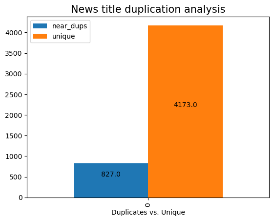

```python
dups_df = pd.DataFrame.from_dict({'near_dups': [dups], 'unique': [uniques]})

ax=dups_df.plot(kind = 'bar',y=['near_dups', 'unique'], fontsize=10, color=['C0', 'C1'], align='center', width=0.8, xlabel="Duplicates vs. Unique")
ax.set_title('News title duplication analysis', fontsize=15)
for p in ax.patches:
       ax.annotate(format(p.get_height(), '.1f'),
                   (p.get_x() + p.get_width() / 2., p.get_height()/2),
                   ha = 'center', va = 'center',
                   xytext = (0, 9),
                   textcoords = 'offset points')
```

# a Jaccard distance of 0.7 means that pairs of sets with a **Jaccard similarity (1 - Jaccard distance) greater than or equal to 0.3 will be considered similar.**

```python
jaccard_distance = 0.7

df_dups_text = model.approxSimilarityJoin(df_hashed_text, df_hashed_text, jaccard_distance).filter("datasetA.id < datasetB.id").select(
            col("distCol"),
            col("datasetA.id").alias("id_A"),
            col("datasetB.id").alias("id_B"),
            col('datasetA.text').alias('text_A'),
            col('datasetB.text').alias('text_B'),
#             col('datasetA.list_of_words').alias('words_A'),
#             col('datasetB.list_of_words').alias('words_B')
            )
```

```python
%%time

df_dups_70 = df_dups_text
df_dups_text.cache()
df_dups_text.limit(5).toPandas()
```

```
24/05/02 05:06:44 WARN org.apache.spark.scheduler.DAGScheduler: Broadcasting large task binary with size 4.1 MiB
24/05/02 05:07:01 WARN org.apache.spark.scheduler.DAGScheduler: Broadcasting large task binary with size 4.3 MiB
[Stage 46:>                                                         (0 + 1) / 1]
```

```
CPU times: user 77.3 ms, sys: 14.7 ms, total: 91.9 ms
Wall time: 3min 31s
```

|  | distCol | id_A | id_B | text_A | text_B |
| --- | --- | --- | --- | --- | --- |
| 0 | 0.346154 | 0 | 4202 | The Daily Ripple-News Music Ideas - Biden team shelves plan to force TikTok sale: ReportThe Daily Ripple-News Music IdeasSwitch to desktopHomeWorld PoliticsU.S. Politics »EconomyFood/HealthArt/Music »… | The Daily Ripple-News Music Ideas - The Gen Z climate activists going viral on TikTokThe Daily Ripple-News Music IdeasSwitch to desktopHomeWorld PoliticsU.S. Politics »EconomyFood/HealthArt/Music »Mus… |
| 1 | 0.374233 | 0 | 3591 | The Daily Ripple-News Music Ideas - Biden team shelves plan to force TikTok sale: ReportThe Daily Ripple-News Music IdeasSwitch to desktopHomeWorld PoliticsU.S. Politics »EconomyFood/HealthArt/Music »… | The Daily Ripple-News Music Ideas - Chinese TikTok influencers apologise for videos of lavish spending including a US$1,500 haircut, US$53,000 bed and a US$61,000 suitThe Daily Ripple-News Music Ideas… |
| 2 | 0.312057 | 0 | 566 | The Daily Ripple-News Music Ideas - Biden team shelves plan to force TikTok sale: ReportThe Daily Ripple-News Music IdeasSwitch to desktopHomeWorld PoliticsU.S. Politics »EconomyFood/HealthArt/Music »… | The Daily Ripple-News Music Ideas - TikTok search results rife with misinformation: ReportThe Daily Ripple-News Music IdeasSwitch to desktopHomeWorld PoliticsU.S. Politics »EconomyFood/HealthArt/Music… |
| 3 | 0.292517 | 0 | 482 | The Daily Ripple-News Music Ideas - Biden team shelves plan to force TikTok sale: ReportThe Daily Ripple-News Music IdeasSwitch to desktopHomeWorld PoliticsU.S. Politics »EconomyFood/HealthArt/Music »… | The Daily Ripple-News Music Ideas - ByteDance: TikTok's co-founder to step down as chief executiveThe Daily Ripple-News Music IdeasSwitch to desktopHomeWorld PoliticsU.S. Politics »EconomyFood/HealthA… |
| 4 | 0.430556 | 2 | 4118 | How a deepfake Tom Cruise on TikTok turned into a very real AI company - USweeklyFriday, 06 August 2021Send search form Todays newsWorldU.S. NationalPoliticsBusinessTechnologySportsEntertainmentBeaut… | TikTok's first family is now streaming. Will its fans follow? - USweeklySaturday, 04 September 2021Send search form Todays newsWorldU.S. NationalPoliticsBusinessTechnologySportsEntertainmentBeauty & … |

```python
records = df_hashed_text.count()
dups = df_dups_text.select('id_A').distinct().count()
uniques = records - dups

print ('Total records: ', records)
print ('Duplicate titles based on {', jaccard_distance, '} jaccard distance: ', dups)
print ('Unique titles based on {', jaccard_distance, '} jaccard distance: ', jaccard_distance, ': ', uniques)
```

```
24/05/02 05:11:21 WARN org.apache.spark.scheduler.DAGScheduler: Broadcasting large task binary with size 4.1 MiB
```

```
Total records:  5000
Duplicate titles based on { 0.7 } jaccard distance:  1407
Unique titles based on { 0.7 } jaccard distance:  0.7 :  3593
```

```
24/05/02 05:11:21 WARN org.apache.spark.scheduler.DAGScheduler: Broadcasting large task binary with size 4.3 MiB
```

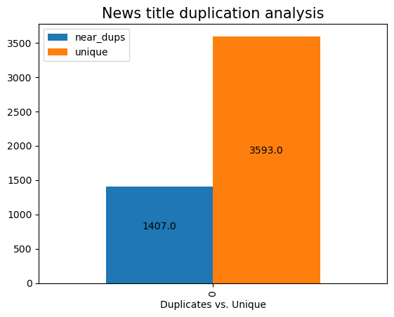

```python
dups_df = pd.DataFrame.from_dict({'near_dups': [dups], 'unique': [uniques]})

ax=dups_df.plot(kind = 'bar',y=['near_dups', 'unique'], fontsize=10, color=['C0', 'C1'], align='center', width=0.8, xlabel="Duplicates vs. Unique")
ax.set_title('News title duplication analysis', fontsize=15)
for p in ax.patches:
       ax.annotate(format(p.get_height(), '.1f'),
                   (p.get_x() + p.get_width() / 2., p.get_height()/2),
                   ha = 'center', va = 'center',
                   xytext = (0, 9),
                   textcoords = 'offset points')
```

# Compare thresholds side-by-side

# Select all pairs of duplicate titles across jaccard similarities

```python
df_dups_30_id = df_dups_30.select(col('id_A').alias('id_30_A'), col('id_B').alias('id_30_B'))
df_dups_50_id = df_dups_50.select(col('id_A').alias('id_50_A'), col('id_B').alias('id_50_B'))
df_dups_70_id = df_dups_70.select(col('text_A'), col('text_B'),\
                                  col('id_A').alias('id_70_A'), col('id_B').alias('id_70_B'))

print(df_dups_30_id.count())
print(df_dups_50_id.count())
print(df_dups_70_id.count())
```

```
24/05/02 05:11:37 WARN org.apache.spark.scheduler.DAGScheduler: Broadcasting large task binary with size 4.3 MiB
```

```
33661
```

```
24/05/02 05:11:37 WARN org.apache.spark.scheduler.DAGScheduler: Broadcasting large task binary with size 4.3 MiB
```

```
35944
45019
```

```
24/05/02 05:11:38 WARN org.apache.spark.scheduler.DAGScheduler: Broadcasting large task binary with size 4.3 MiB
```

```python
# Less the dups the better.
# a Jaccard distance of 0.3 means that pairs of sets with a **Jaccard similarity (1 - Jaccard distance) greater than or equal to 0.7 will be considered similar.**

# Recommendation
```

[output not shown]

[output not shown]

```python
data = [df_dups_30_id.count(), df_dups_50_id.count(), df_dups_70_id.count()]
data
```

```
24/05/02 05:13:16 WARN org.apache.spark.scheduler.DAGScheduler: Broadcasting large task binary with size 4.3 MiB
24/05/02 05:13:17 WARN org.apache.spark.scheduler.DAGScheduler: Broadcasting large task binary with size 4.3 MiB
24/05/02 05:13:18 WARN org.apache.spark.scheduler.DAGScheduler: Broadcasting large task binary with size 4.3 MiB
```

```
[33661, 35944, 45019]
```

# Build a histogram showing the overall distribution of “near-duplication”

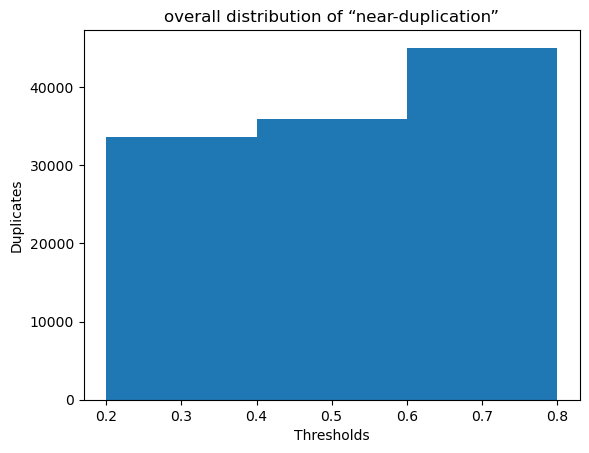

```python
import matplotlib.pyplot as plt

bin_edges = [ 0.3, 0.5, 0.7]
bin_labels = ['0.3', '0.5', '0.7']

plt.bar(bin_edges, data, width = 0.2)
#bin_midpoints = [(bin_edges[i] + bin_edges[i+1])/2 for i in range(len(bin_edges)-1)]
#plt.xticks(bin_midpoints, bin_labels)
plt.xlabel('Thresholds')
plt.ylabel('Duplicates')
plt.title('overall distribution of “near-duplication”')
plt.show()
```